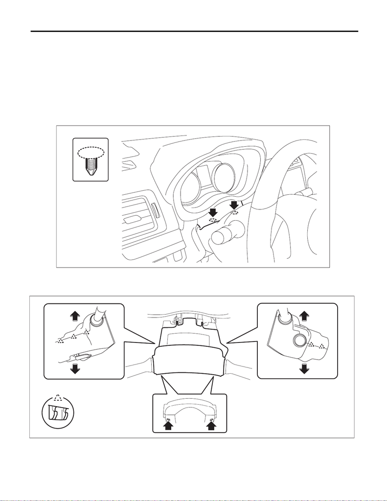

SL-66

Key Lock Cylinders

SECURITY AND LOCKS

19.Key Lock Cylinders

A: REMOVAL

1. STEERING LOCK

1) Disconnect the ground cable from battery and wait for at least 60 seconds before starting work. <Ref. to

NT-5, BATTERY, NOTE, Note.>

NOTE:

For models other than STI model, disconnect the ground terminal from battery sensor.

2) Remove the cover assembly - column.

(1) Remove the clips, and remove the cover - column.

(2) Remove the screws by turning the steering wheel to right and left.

(3) Release the claw, and remove the cover assembly - column UPR and the cover assembly - column

LWR.

3) Remove the immobilizer antenna assembly. <Ref. to SL-88, REMOVAL, Immobilizer Antenna.>

PS-01710

LI-01207

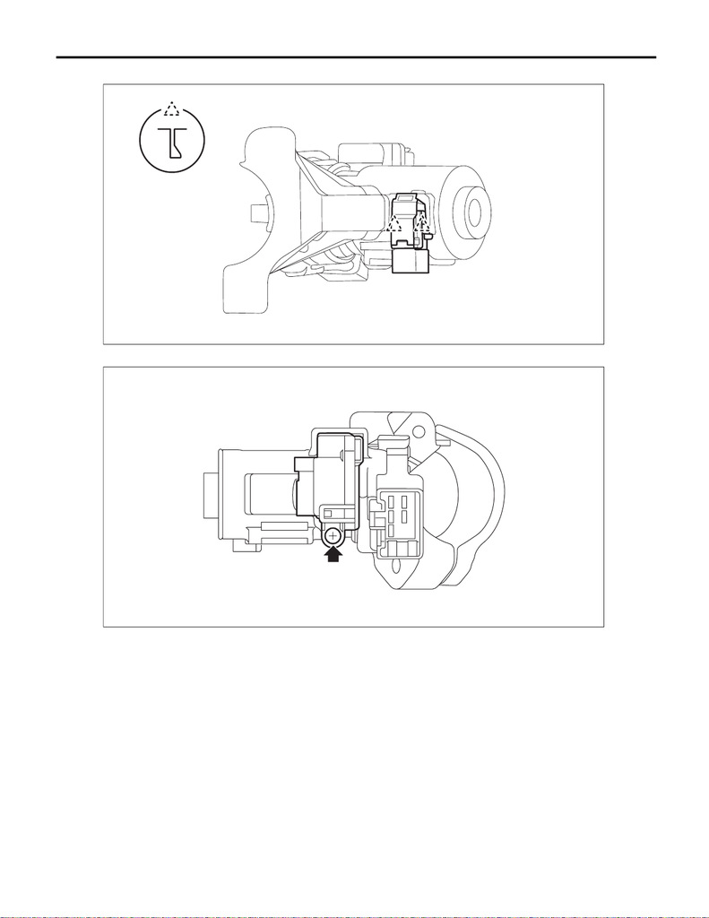

SL-67

Key Lock Cylinders

SECURITY AND LOCKS

4) Release the claws, and pull the key warning switch downwards to remove.

SL-01535

SL-01536

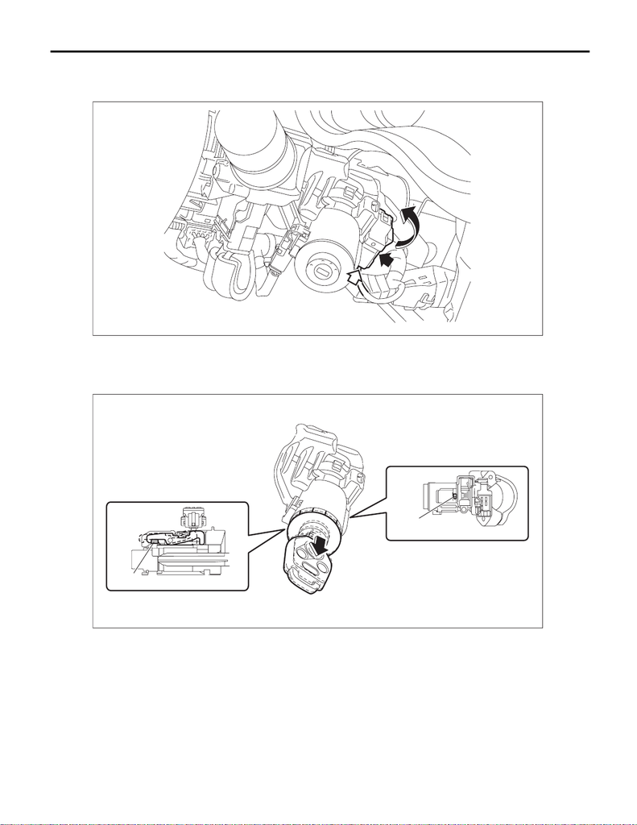

SL-68

Key Lock Cylinders

SECURITY AND LOCKS

6) Remove the key lock solenoid.

(1) Disconnect the connector.

(2) Remove the screws and remove the key lock solenoid.

7) Replace the key cylinder.

(1) Insert the key into the key cylinder, and turn the key to the ACC position.

(2) Insert a flat tip screwdriver from the steering lock frame hole (A), and pull the key cylinder until the key

cylinder claws touch the steering lock frame stopper (B).

SL-01538

SL-01524

(B)

(A)

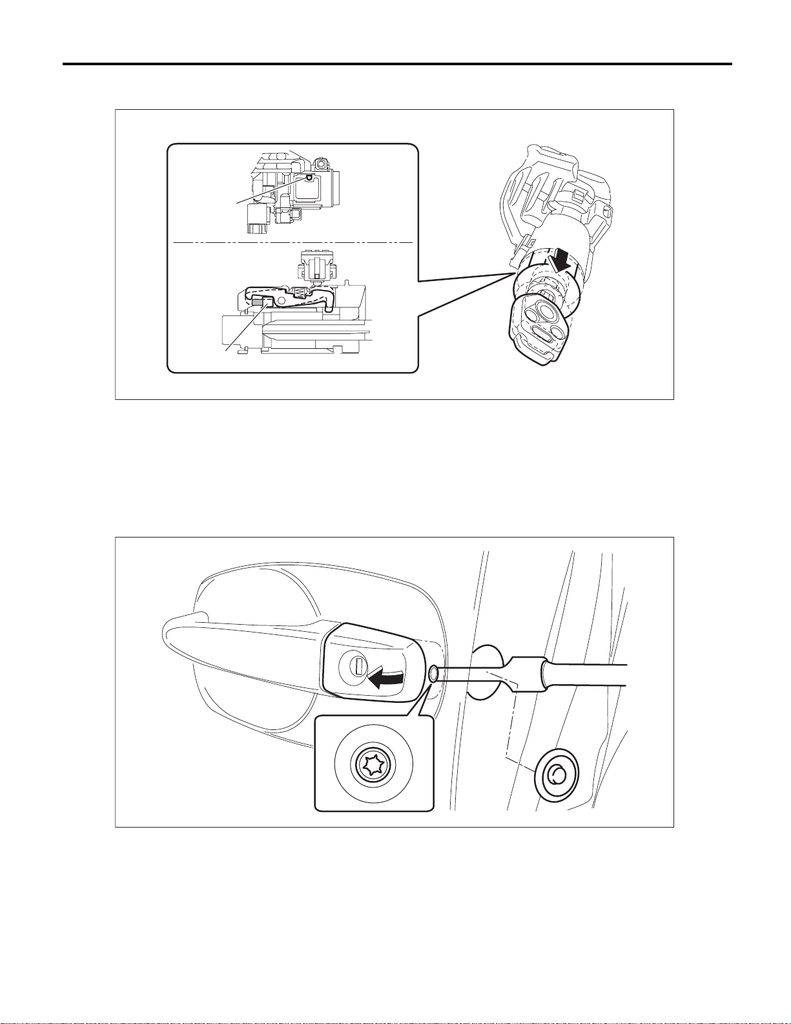

SL-69

Key Lock Cylinders

SECURITY AND LOCKS

(3) Insert a flat tip screwdriver from the steering lock frame hole (A), and release the claws to pull out the

key cylinder.

2. FRONT DOOR

1) Raise the glass assembly - front door to the top position.

2) Remove the cover - handle front outer.

Preparation tool:

TORX

®

T30

(1) Remove the plug at the rear end of the panel assembly - front door.

(2) Loosen the TORX

®

bolt and remove the cover - handle front outer.

SL-01525

(A)

(A)

SL-01175

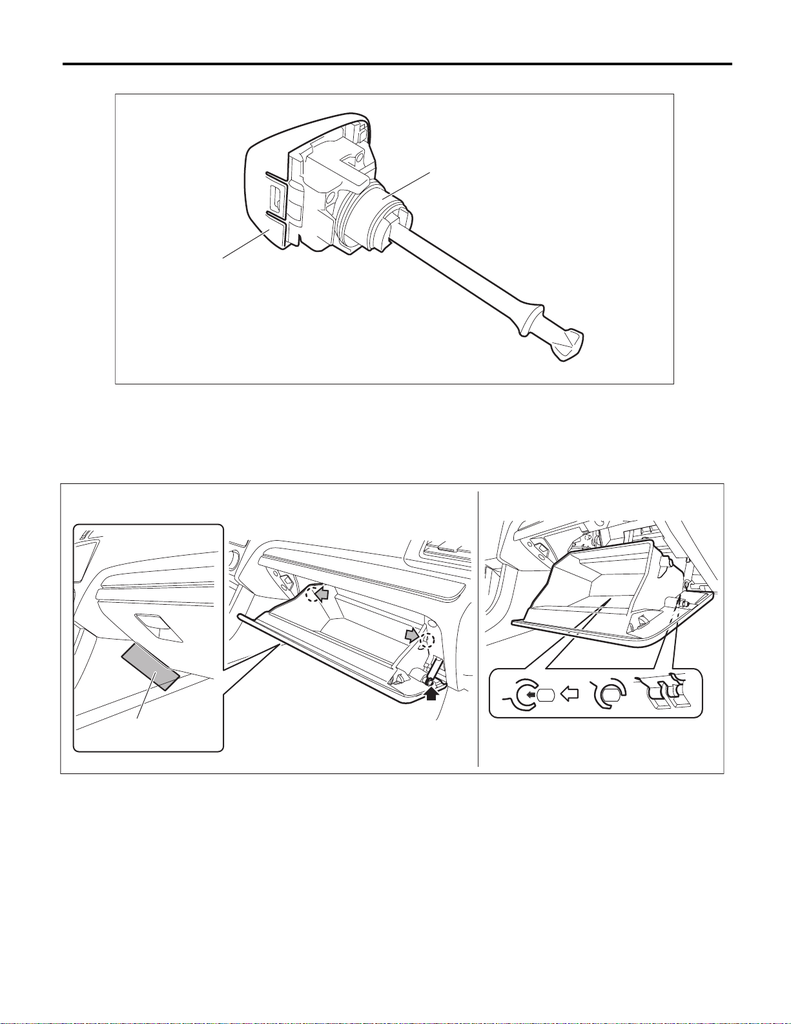

SL-70

Key Lock Cylinders

SECURITY AND LOCKS

3) Remove the key cylinder (B) from the cover - handle front outer (A), and replace the key cylinder.

3. GLOVE BOX LID

1) Remove the pocket assembly.

(1) Attach the protective tape (a) to the panel center LWR.

(2) Remove the damper COMPL - pocket.

(3) Release the stoppers and remove the pocket assembly by pulling it toward you.

SL-01527

(A)

(B)

EI-03419

(a)

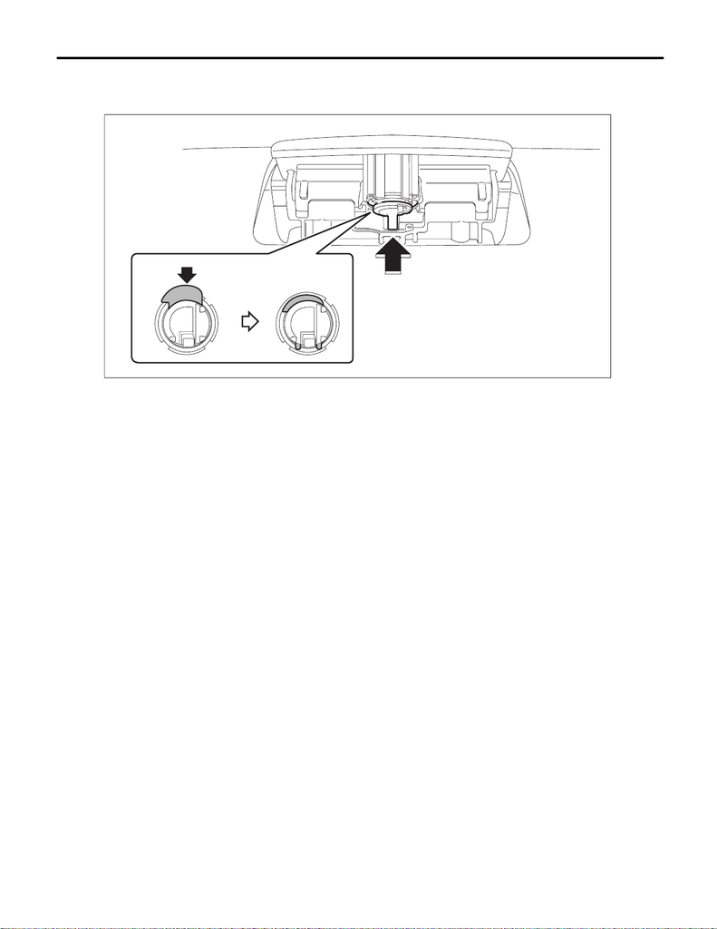

SL-71

Key Lock Cylinders

SECURITY AND LOCKS

2) Replace the key cylinder.

(1) Pull up the lock knob.

(2) Push out the key cylinder from the pocket assembly while pressing in the metal plate.

B: INSTALLATION

1. STEERING LOCK

1) Install the key cylinder.

2) Install the key lock solenoid and immobilizer antenna assembly.

3) Install the cover assembly - column.

4) Connect the battery ground terminal. <Ref. to NT-5, BATTERY, NOTE, Note.>

NOTE:

For models other than STI model, connect the ground terminal to battery sensor.

2. FRONT DOOR

1) Install the key cylinder.

2) Install the cover - handle front outer.

CAUTION:

When installing the cover - handle front outer on driver’s side, make sure that the key cylinder shaft

is correctly inserted into the latch & actuator assembly - front.

Preparation tool:

TORX

®

T30

Tightening torque:

7.5 N·m (0.8 kgf-m, 5.5 ft-lb)

3. GLOVE BOX LID

1) Install the key cylinder.

2) Install the pocket assembly.

SL-01528